# 06-order-statistics

Sriram Kannan

10-25-2021

# 1 Introduction

In this blog post, we examine Which quantiles of a continuous distribution can one estimate with more precision? We answer a series of questions related to the variation of the median (and a range of other quantiles) using analytical methods.The median is an important quantity in data analysis. It represents the middle value of the data distribution. Estimates of the median, however, have a degree of uncertainty because (a) the estimates are calculated from a finite sample and (b) the data distribution of the underlying data is generally unknown.

# 2 Questions

Q: Begin with the median from a sample of N=200 from the standard normal distribution. Write an R function that is the density function for the median in this sample. Note that the 100th order statistic is approximately the median, and use the order statistic formula discussed in class. Generate a plot of the function.

The following function is based off the Probability Density function of the kth Order Statistic Formula.

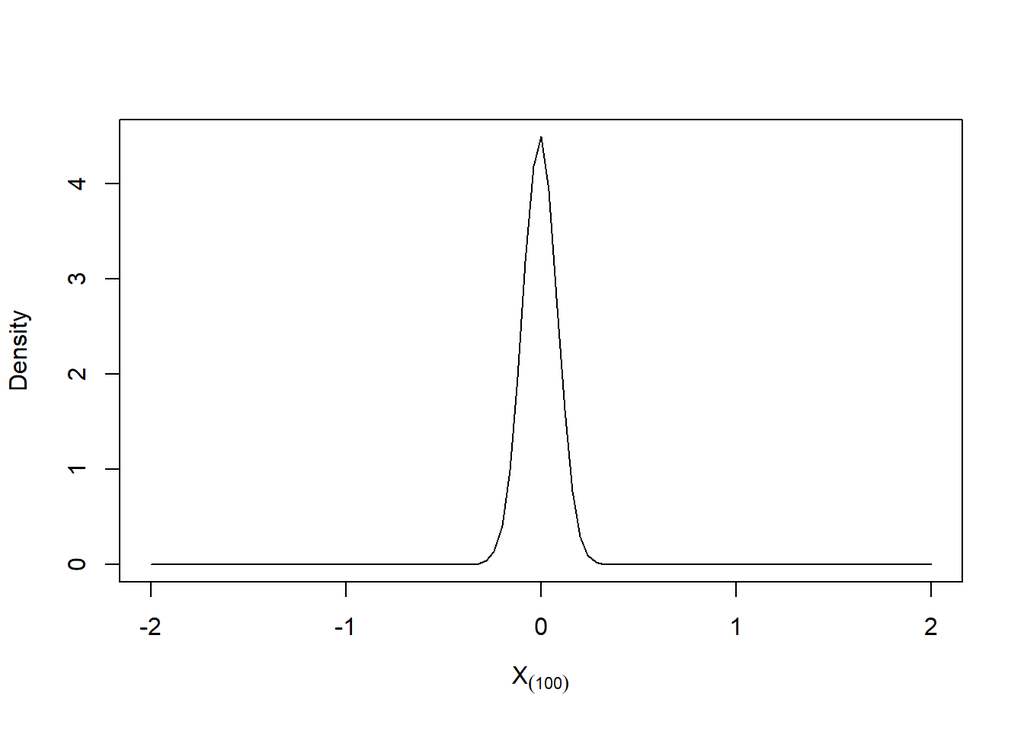

```r
dorder <- function(x,k,n){
  k*
  choose(n,k)*
  (pnorm(x, 0, 1))^(k-1)*
  (1-pnorm(x, 0, 1))^(n-k)*
  dnorm(x, 0, 1)
}


curve(
    dorder(x, 100, 200)
  , -2
  , 2
  , xlab = parse(text="X[(100)]")
  , ylab = "Density"
)
```

The above plot is the density function of the median in a sample of 200 in a standard normal distribution with mean = 0 and standard deviation = 1.

Q: Write an R function that is the probability function for the median in this sample. Use the order statistic formula discussed in class. Generate a plot of the function.

The following function is based off the Cumulative Distribution function of the kth Order Statistic Formula.

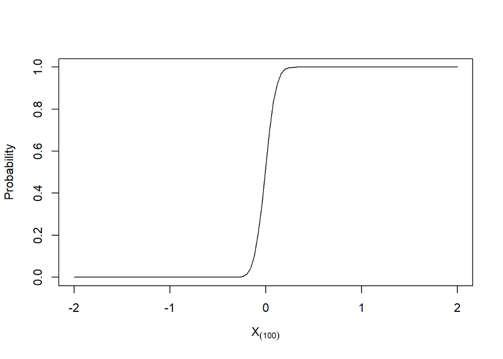

```r
porder <- function(x,k,n){
  pbinom(k-1, n, pnorm(x, 0, 1), lower.tail = FALSE)
}

curve(
    porder(x, 100, 200)
  , -2
  , 2
  , xlab = parse(text="X[(100)]")
  , ylab = "Probability"
)
```

The above plot is the probability function of the median in a sample of 200 in a standard normal distribution with mean = 0 and standard deviation = 1.

Q: Write an R function that is the quantile function for the median in this sample. Generate a plot of the function.

```r
library(tidyverse)
```

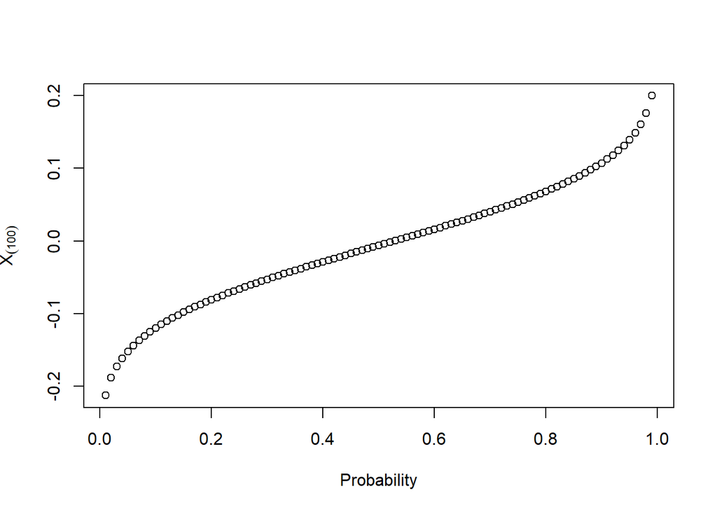

```r
k = 100
n = 200

qorder <- function(p, k, n){
  output <- NA
  for (i in seq_along(p)) {
    f <- function(x,p){
    return(porder(x)-p[i])
    }
    output[i] <- uniroot(function(x) {porder(x, k, n)-p[i]}, c(-100, 100))$root
  }
  return(output)
}

p <- seq(.01, .99, by = .01)

plot(p, qorder(p, 100, 200), xlab = "Probability", ylab = parse(text="X[(100)]"))
```

The above plot is the quantile function of the median in a sample of 200 in a standard normal distribution with mean = 0 and standard deviation = 1.

Q: Simulate the sampling distribution for the median. Create a plot of the empirical CDF (ECDF). Overlay the plot of the ECDF with a plot of the CDF.

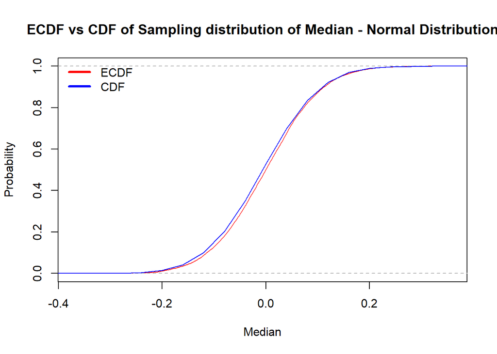

```r
library(tidyverse)
median <- array(NA, dim = c(10000,1))
for(i in 1:nrow(median))
  {
    median[i, 1] <- rnorm(200, 0, 1) %>% median
  }
plot(ecdf(median), xlab = "Median", ylab = "Probability", main = "ECDF vs CDF of Sampling distribution of Median - Normal Distribution", col = "red")
curve(porder(x, 100, 200), -2, 2, add = TRUE, col = "blue")
legend("topleft", c("ECDF","CDF"), lwd = 3, col = c("red","blue"), bty = "n")
```

The above plot overlays the ECDF with the CDF of the median of a standard normal distribution with mean = 0 and standard deviation = 1 The ECDF and the CDF match pretty closely throughout.

Q: Using the simulated sampling distribution from the previous question, create a histogram (on the density scale). Overlay the histogram with a plot of the density function.

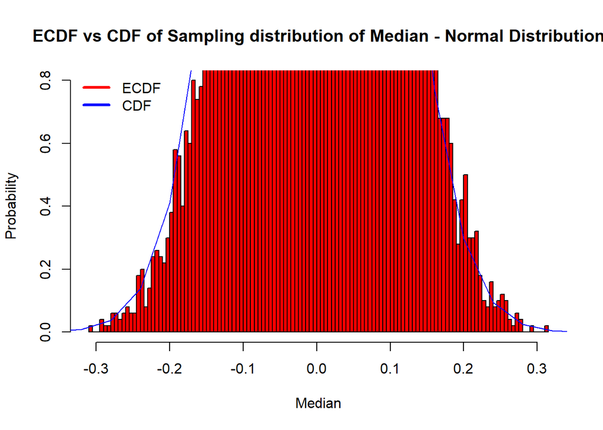

```r
median <- array(NA, dim = c(10000,1))
for(i in 1:nrow(median))
  {
    median[i, 1] <- rnorm(200, 0, 1) %>% median
  }
hist(median, freq = FALSE, breaks = 100, xlab = "Median", ylab = "Probability", main = "ECDF vs CDF of Sampling distribution of Median - Normal Distribution", col = "red", ylim = c(0.0, 0.8))
curve(dorder(x, 100, 200), -2, 2, ylim = c(0,1), add = TRUE, col = "blue")
legend("topleft", c("ECDF","CDF"), lwd = 3, col = c("red","blue"), bty = "n")
```

Q: One very common way to compare a random sample to a theoretical candidate distribution is the QQ plot. It is created by ploting quantiles of the theoretical distribution on the x-axis and empirical quantiles from the sample on the y-axis.

```r
library(tgsify)
library(magrittr)
```

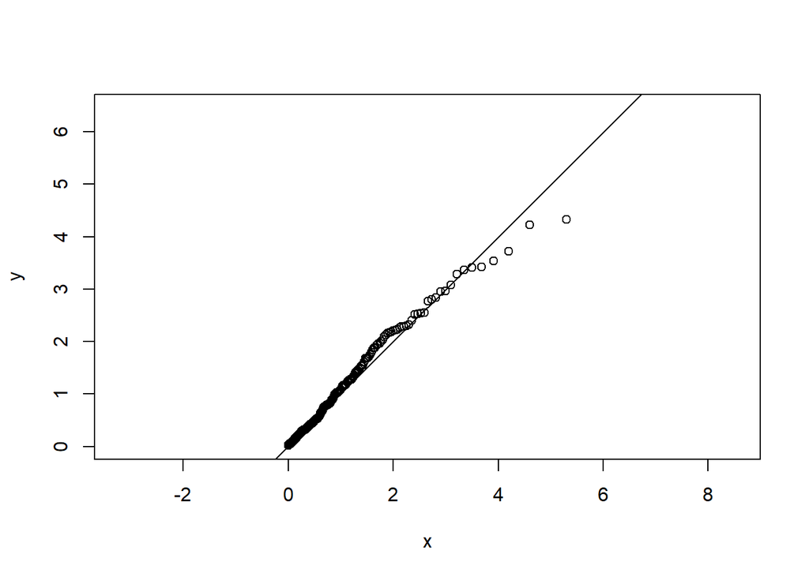

```r
random_sample <- rexp(200)
q_candidate <- qexp

x <- q_candidate((1:200)/200)
y <- quantile(random_sample, probs = (1:200)/200)
#
plot(x,y, asp = 1)
abline(0,1)
```

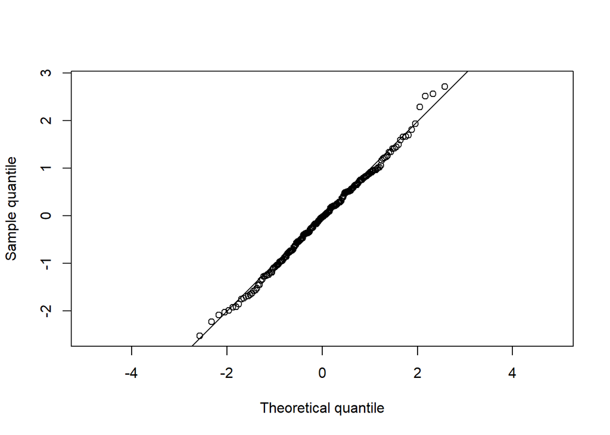

```r
#
random_sample <- rnorm(200)
 q_candidate <- qnorm
 x <- q_candidate((1:200)/200)
y <- quantile(random_sample, probs = (1:200)/200)
 plot(x,y, asp = 1, xlab = "Theoretical quantile", ylab = "Sample quantile")
 abline(0,1)
```

The QQ plot above shows the comparison between a random sample and the candidate distribution through plotting of theoretical quantiles and empirical quantiles from the sample. There seem to be little deviation between the two.

Q: Generate a QQ plot for the simulated data of the median relative to the known sampling distribution of the median. Does the simulated data agree with the theoretical sampling distribution?

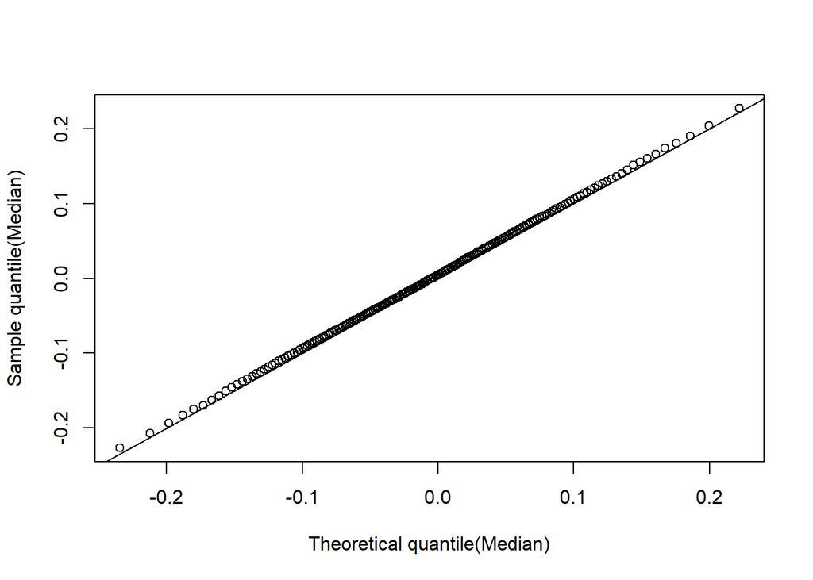

```r
median <- array(NA, dim = c(10000,1))
for(i in 1:nrow(median))
  {
    median[i, 1] <- rnorm(200, 0, 1) %>% median
  }

random_sample <- median
q_candidate <- qorder

tm <- q_candidate((1:199)/200, 100, 200)
sm <- quantile(median, probs = (1:199)/200)

plot(tm,sm, xlab = "Theoretical quantile(Median)", ylab = "Sample quantile(Median)")
abline(0,1)
```

The above plot is the QQ plot for the simulated data of the median relative to the known sampling distribution of the median. They simulated data closely agrees with the theoretical sampling distribution.

Q: Modify the dorder, porder, and qorder functions so that the functions take a new parameter k (for the kt**h order statistic) so that the functions will work for any order statistic and not just the median.

```r
dorder <- function(x,k,n){
  k*
  choose(n,k)*
  (pnorm(x, 0, 1))^(k-1)*
  (1-pnorm(x, 0, 1))^(n-k)*
  dnorm(x, 0, 1)
}

porder <- function(x,k,n){
  pbinom(k-1, n, pnorm(x, 0, 1), lower.tail = FALSE)
}

qorder <- function(p, k, n){
  output <- NA
  for (i in seq_along(p)) {
    f <- function(x,p){
    return(porder(x)-p[i])
    }
    output[i] <- uniroot(function(x) {porder(x, k, n)-p[i]}, c(-100, 100))$root
  }
  return(output)
}
```

The functions dorder, porder and qorder were already generalized and can take a new parameter k for the kth order statistic and not just the median.

Q: Generate the QQ plot for simulated data from the sampling distribution of the sample max and the theoretical largest order statistic distribution.

We use the last order Statistic, in this case 200 as the sample size is 200 for the maximum.

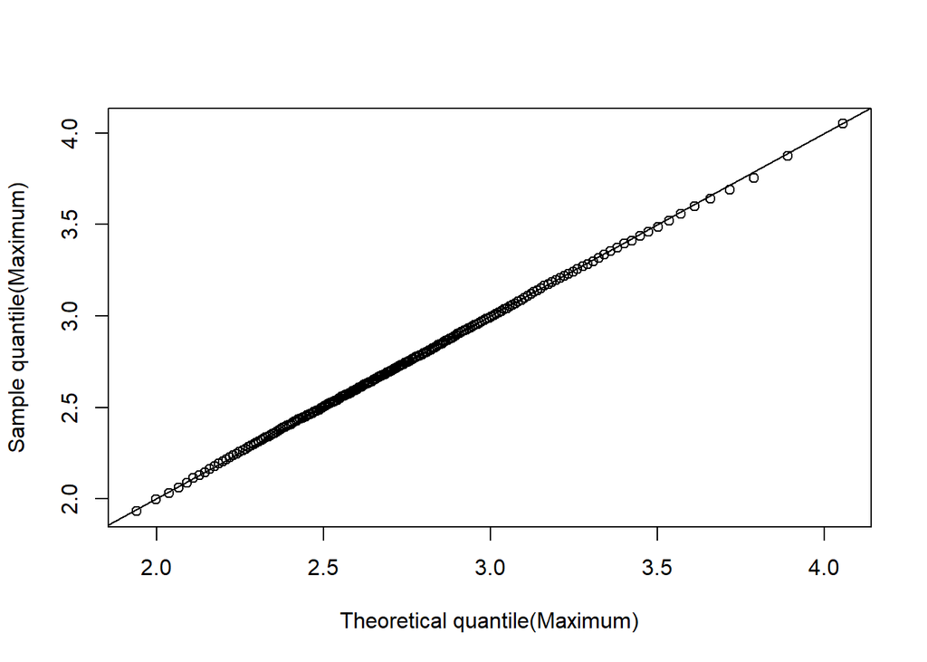

```r
max <- array(NA, dim = c(10000,1))
for(i in 1:nrow(max))
  {
    max[i, 1] <- rnorm(200, 0, 1) %>% max
  }

random_sample <- max
q_candidate <- qorder

x <- q_candidate((1:199)/200, 200, 200)
y <- quantile(max, probs = (1:199)/200)

plot(x,y, xlab = "Theoretical quantile(Maximum)", ylab = "Sample quantile(Maximum)")
abline(0,1)
```

Q: Modify the dorder, porder, and qorder functions so that the functions take new parameters dist and … so that the functions will work for any continuous distribution that has d and p functions defined in R.

```r
dorder <- function(x,k,n,dist="norm",...){
  F <- eval(parse(text="p" %|% dist))
  f <- eval(parse(text="d" %|% dist))
  k*
    choose(n,k)*
    (F(x, ...))^(k-1)*
    (1-F(x, ...))^(n-k)*
    f(x, ...)
}

porder <- function(x,k,n,dist="norm",...){
  F <- eval(parse(text="p" %|% dist))
  f <- eval(parse(text="d" %|% dist))
  pbinom(k-1, n, (F(x, ...)), lower.tail = FALSE)
}


qorder <- function(p, k, n, dist="norm",...){
  output <- NA
  for (i in seq_along(p)) {
    f <- function(x,p){
    return(porder(x)-p[i])
    }
    output[i] <- uniroot(function(x) {porder(x, k, n, dist="norm",...)-p[i]}, c(-100, 100))$root
  }
  return(output)
}
```

Q: Use the newly modified functions to plot the probability and density functions for the sample min (N=200).

The sample minimum is represented by the First Order Statistic.

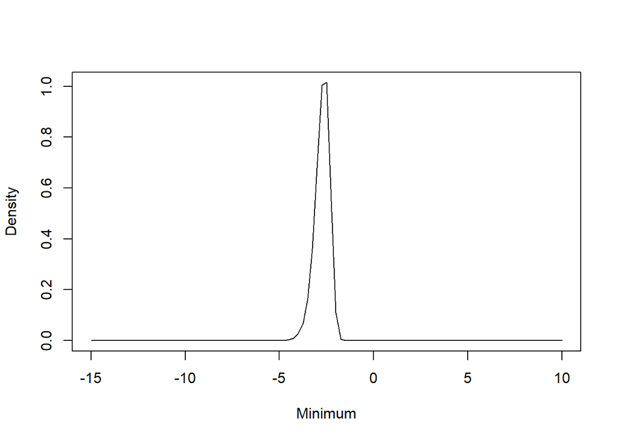

```r
n = 200
k = 1
curve(
    dorder(x, 1, 200, mean = 0, sd = 1)
  , -15
  , 10
  , xlab = "Minimum"
  , ylab = "Density"
)
```

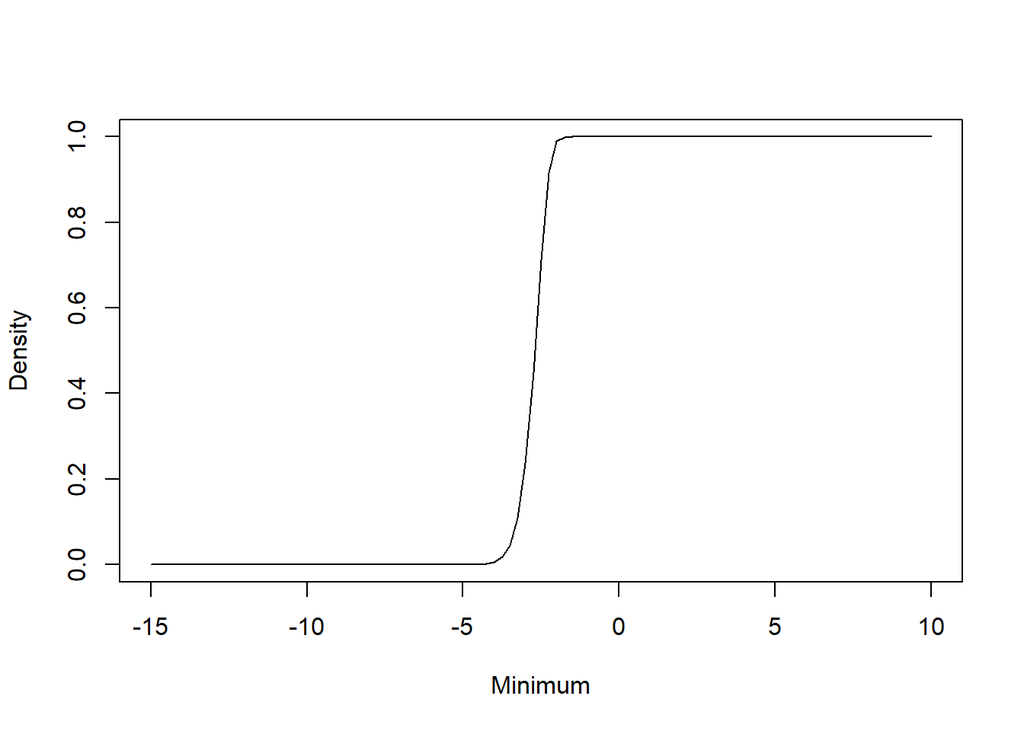

```r
curve(
    porder(x, 1, 200, mean = 0, sd = 1)
  , -15
  , 10
  , xlab = "Minimum"
  , ylab = "Density"
)
```

The plots above represent the Density and the Probability functions for the Sample Minimum in a Normal Distribution with Mean = 0 and Standard Deviation = 1.